# Analiza ankete

## Pretpostavke

U anketi je sudjelovalo 259 ispitanika. Razmatranja iz ankete vrijede sigurno za prikupljeni uzorak ljudi, ali ne mogu se generalizirati na cijelu populaciju mladih (15-25 godina) u Republici Hrvatskoj zbog sljedećih razloga:

1. Anketa je bila online. Iako je danas većina mladih dobro upoznata s uslugama Interneta i koristi ih na dnevnoj bazi, postoji udio mladih koji nisu često na Internetu ili ga uopće ne koriste, tako da taj udio je isključen iz analize ankete
2. Većina ispitanika je iz područja Grada Zagreba (55%) što također utječe na reprezentabilnost uzorka i generaliziranje na cijelu populaciju. Smatra se da ako su ispitanici iz iste županije da postoji veći koeficijent zavisnosti među njima ( npr. prijatelj je mogao utjecati na odgovore drugog prijatelja jer imaju vrlo sličnu lokaciju prebivanja, općenito socijalni status i način življenja im se ne razlikuje previše). U idealnom slučaju bi proporcije raspodjele ispitanika po županijama odgovarale raspodjeli stanovništva hrvatske po županijama
3. 82% ispitanika su studenti, a 90% ispitanika ima između 19-25 godina. To ukazuje da u anketi nedostaje ispitanika koji pohađaju srednju školu i aktivno rade. Razumno je pretpostaviti da mladi između 15 i 18 godina nemaju još otvoren račun u banci jer se roditelji brinu o njihovim financijama stoga ih ni anketa nije zanimala što je rezultiralo niskim odazivom tog dijela populacije. Ako se sagleda generalna situacija, srednjoškolci općenito nisu još upoznati s bankarskim usluga, pa je logično da primarna populacija ankete nisu bili oni, već ostatak populacije koji redovno koristi bankarske usluge jer nam upravo taj ostatak može dati povratnu informaciju.
4. Kod analize grafova gdje se koristi statistički račun se pretpostavlja da razdiobe prate normalnu razdiobu. Uvjeti koji su potrebni za normalnu razdiobu su:
   - Nezavisnost subjekata te se taj uvjet inače zadovoljava tako da je broj subjekata u uzorku manji od 10% populacije. Naša anketa zadovoljava taj uvjet no javljaju se drugi problemi vezani uz zavisnost koji su gore opisani
   - Broj subjekata mora biti veći od 30 da bi distribucija pratila normalnu distribuciju. Taj uvjet je također zadovoljen
   - Graf raspodjele ne smije biti previše nagnut ni na koju stranu. Smije biti nagnut blago, ali samo ako je veličina uzorka dovoljno velika što naše istraživanje zadovoljava.
   - Standardna devijacija ne bi smjela biti previše izražena jer bi to značilo da postoje mjerenja koja jako odstupaju od ostalih. Mi nismo imali takvih slučajeva i devijacija nam je bila prihvatljiva tako da smo zadovoljili taj uvjet.

## Analiza

### Raspodjela spolova

```
## [1] "Udio u postocima"
```

```
##
##    Muško   Žensko
## 43.35938 56.64062
```

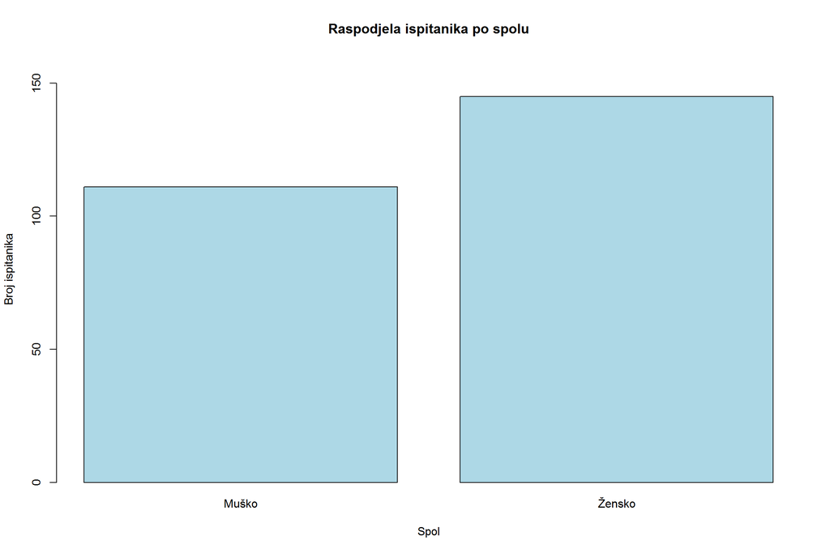

Kao što se može vidjeti iz grafa, udio ženske populacije je malo viši udjela muške populacije.

### Raspodjela po godinama

```
## [1] "Udio u postocima"
```

```
## godine
## Manje od 15 Od 15 do 18 Od 19 do 25  Više od 25
##    0.390625    2.343750   90.625000    6.640625
```

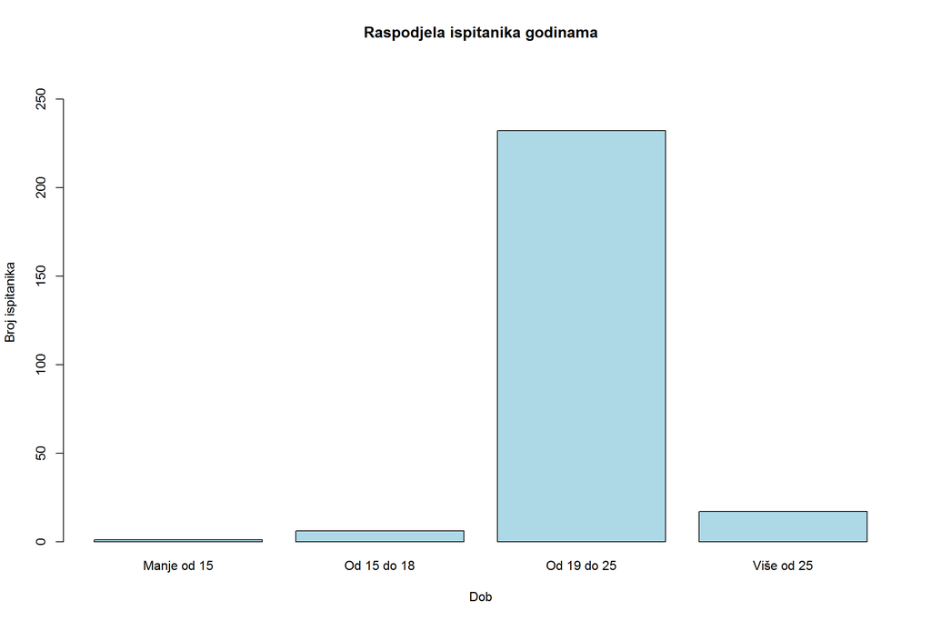

Većina ispitanika je imala između 19 i 25 godina. Taj podatak je zadovoljavajuć jer je upravo to bila ciljana populacija, iako je trebalo biti više ispitanika koji imaju između 15 i 18 godina.

### Raspodjela po radnom statusu

```
## [1] "Udio u postocima"
```

```
##
##             Nezaposlen/a         Srednjoškolac/ka              Student/ica
##                 2.734375                 1.953125                82.031250
## Student/ica + zaposlen/a               Zaposlen/a
##                 6.250000                 7.031250
```

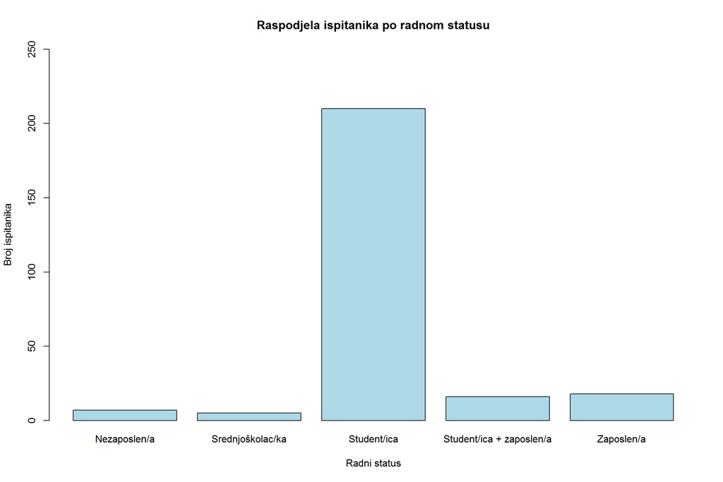

Analiza varijable radnog stanja potvrđuje da smo pogodili ciljanu populaciju. Uočljivo je da visok postotak ispitanika ima radni status studenta što je i za očekivati, no udio zaposlenih bi trebao biti veći jer je za očekivati da zaposleni češće koriste bankarske usluge te bi zbog toga oni davali najbolju korisnu informaciju jer imaju najviše iskustva s bankom.

### Parametri prema kojima se ljudi određuju za banke

```
## [1] "Udio u postocima"
```

```
## why
##     Najbolji uvjeti i pogodnosti                           Ostalo
##                        16.406250                         6.640625
## Preporuka prijatelja ili rodbine                    Pristupačnost
##                        46.484375                        30.468750
```

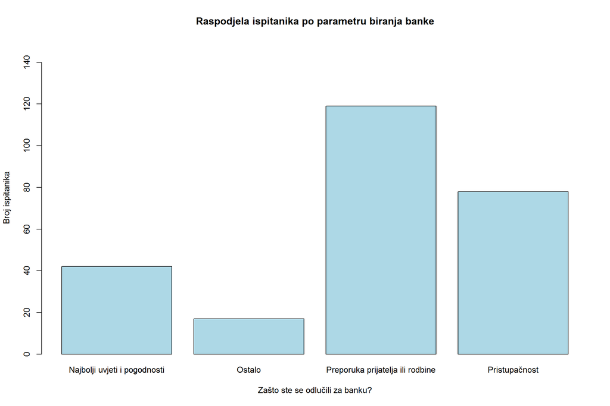

Pristupačnost i preporuka odstupaju od prosjeka čime se ukazuje da mladi ne biraju banke po uvjetima koji im nude što bi bilo najbolje za njih. To bi trebalo promijeniti jer vrlo je vjerojatno da ako se odluči za određenu banku da će ju koristiti na duži period.

### Učestalost korištenja bankomata

```
## [1] "Udio u postocima"
```

```
##
##  Dva do četiri puta tjedno              Jednom tjedno
##                  14.062500                  29.296875
##        Jednom u dva tjedna       Ne koristim bankomat
##                  40.234375                  13.671875
## Više od četiri puta tjedno
##                   2.734375
```

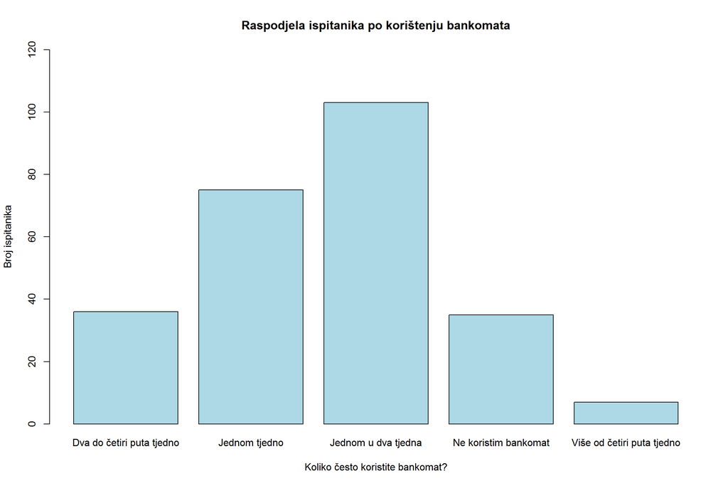

Korištenje bankomata nije previše izraženo (prosjek je između jedom u dva tjedna i jednom tjedno).

### Ocjena bankarskih usluga koje se nude

```r
#Prilagođavanje podataka

paste("Statistika")
```

```
## [1] "Statistika"
```

```r
summary(tablicaMain$ScoreBankingServices)
```

```
##    Min. 1st Qu.  Median    Mean 3rd Qu.    Max.
##   0.000   2.000   3.000   3.074   4.000   6.000
```

```r
##Mean
est= mean(tablicaMain$ScoreBankingServices)

paste("Udio u postocima")
```

```
## [1] "Udio u postocima"
```

```r
prop.table(table(tablicaMain$ScoreBankingServices))*100
```

```
##
##         0         1         2         3         4         5         6
##  3.125000  8.203125 17.187500 39.843750 17.187500 10.156250  4.296875
```

```r
sd=sd(tablicaMain$ScoreBankingServices)

paste("Standardna devijacija: " , sd)
```

```
## [1] "Standardna devijacija:  1.3218968007983"
```

```r
#Račun područja pouzdanosti (95%)
error <- qnorm(0.975)*sd/sqrt(nrow(tablicaMain))
left <- est-error
right <- est+error

paste("Interval pouzdanosti od 95% je :" ,left, " - ", right)
```

```
## [1] "Interval pouzdanosti od 95% je : 2.91228936744729  -  3.23614813255271"
```

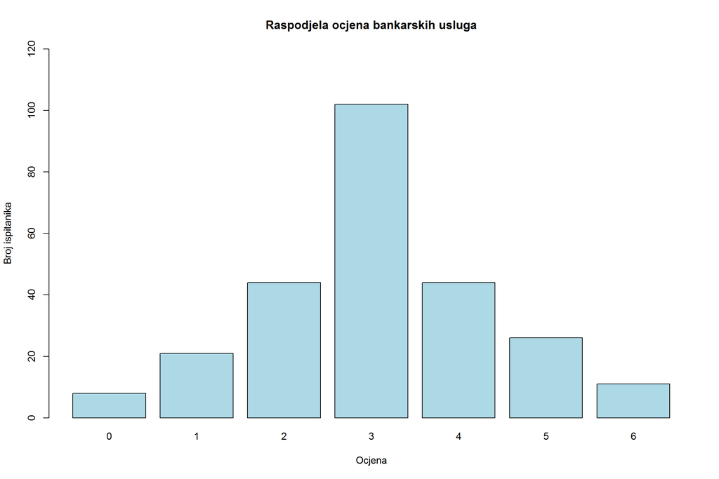

```r
barplot(table(tablicaMain$ScoreBankingServices), col=c("lightblue"), ylim = c(0, 120), xlab="Ocjena", ylab="Broj ispitanika", main="Raspodjela ocjena bankarskih usluga")
```

Prosječna ocjena je 3.07 (interval od 0 do 6). Standardna devijacija je 1.32. Računom dobivamo da je interval pouzdanosti od 95% jednak od 2.91 do 3.24. Zaključke ne možemo dovoditi zbog upitne nezavisnosti podataka i nedostatka ispitanika iz određenih dobnih skupina.

### Ocjena Internet sigurnosti

```
## [1] "Statistika"
```

```
##    Min. 1st Qu.  Median    Mean 3rd Qu.    Max.
##   1.000   2.000   3.000   3.022   4.000   5.000
```

```
## [1] "Udio u postocima"
```

```
## safety
##         1         2         3         4         5
## 11.688312 18.181818 34.632035 27.272727  8.225108
```

```
## [1] "Standardna devijacija:  1.12073689828685"
```

```
## [1] "Interval pouzdanosti od 95% je : 2.87711909199266  -  3.16617095129738"
```

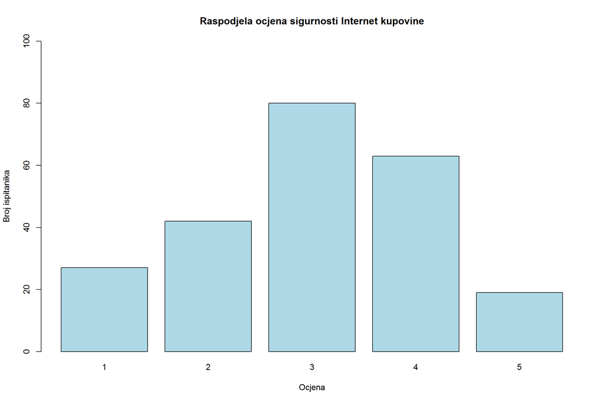

Prosječna ocjena je 3.02 (interval od 1 do 5). Standardna devijacija je 1.12 . Računom dobivamo da je interval pouzdanosti od 95% jednak od 2.88 do 3.17. Zaključke ne možemo dovoditi zbog upitne nezavisnosti podataka i nedostatka ispitanika iz određenih dobnih skupina. Graf je blago nagnut na desno, no to nije dovoljno dobar indikator da se mladi osjećaju sigurnije na internetu od prosjeka (prosjek populacije se uzima da je 3).

### Ocjena sigurnosti Internet bankarstva

```
## [1] "Statistika"
```

```
##    Min. 1st Qu.  Median    Mean 3rd Qu.    Max.
##   1.000   2.000   3.000   3.278   4.000   5.000
```

```
## [1] "Udio u postocima"
```

```
## safety
##        1        2        3        4        5
## 10.12658 15.18987 27.84810 30.37975 16.45570
```

```
## [1] "Standardna devijacija:  1.20313899679652"
```

```
## [1] "Interval pouzdanosti od 95% je : 3.12530536629373  -  3.43165665902273"
```

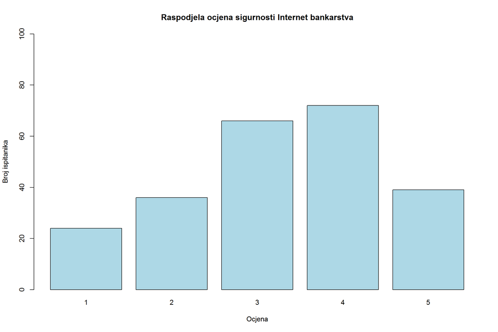

Prosječna ocjena je 3.27 (interval od 1 do 5). Standardna devijacija je 1.20 . Računom dobivamo da je interval pouzdanosti od 95% jednak od 3.12 do 3.43.

Uz pretpostavku da je prosječna ocjena populacije za sigurnost jednaka 3, možemo provjeriti dali ova skupina odstupa od populacije. Početna pretpostavka nam je da odstupanja nema tj. razlika između prosječne ocjene u ovoj skupini i prosječne ocjene populacije je jednaka nuli. Alternativna hipoteza je da je ocjena ove skupine veća od ocjene prosječne populacije.

Uz malo računa se dobiva da je p vrijednost jednaka 0.00018 što je manje od razine signifikantnosti od 0.01 (uzeli smo manju razinu signifikantnosti zbog upitne nezavisnosti podataka i nedostatka ispitanika iz određenih dobnih skupina), te na temelju toga odbacujemo početnu hipotezu. Ovim razmatranjem možemo povući samo asocijativnu vezu da mladi bolje ocjenjuju sigurnost internet bankarstva od populacije.

### Ocjena pogodnosti koje se nude mladima

```r
paste("Statistika")
```

```
## [1] "Statistika"
```

```r
benefits = na.omit(tablicaMain$YouthBenefits)

summary(benefits)
```

```
##    Min. 1st Qu.  Median    Mean 3rd Qu.    Max.
##    1.00    3.00    4.00    4.18    5.00    8.00
```

```r
##Mean
est= mean(benefits)

paste("Tablica frekvencija")
```

```
## [1] "Tablica frekvencija"
```

```r
prop.table(table(benefits))*100
```

```
## benefits
##         1         2         3         4         5         6         7
##  8.593750  8.593750 11.328125 25.781250 28.125000 11.328125  3.515625
##         8
##  2.734375
```

```r
sd= sd(benefits)

paste("Standardna devijacija: " , sd)
```

```
## [1] "Standardna devijacija:  1.64225380164566"
```

```r
#Račun područja pouzdanosti (95%)
error <- qnorm(0.975)*sd/sqrt(length(safety))
left <- est-error
right <- est+error

paste("Interval pouzdanosti od 95% je :" ,left, " - ", right)
```

```
## [1] "Interval pouzdanosti od 95% je : 3.97060668038446  -  4.38876831961554"
```

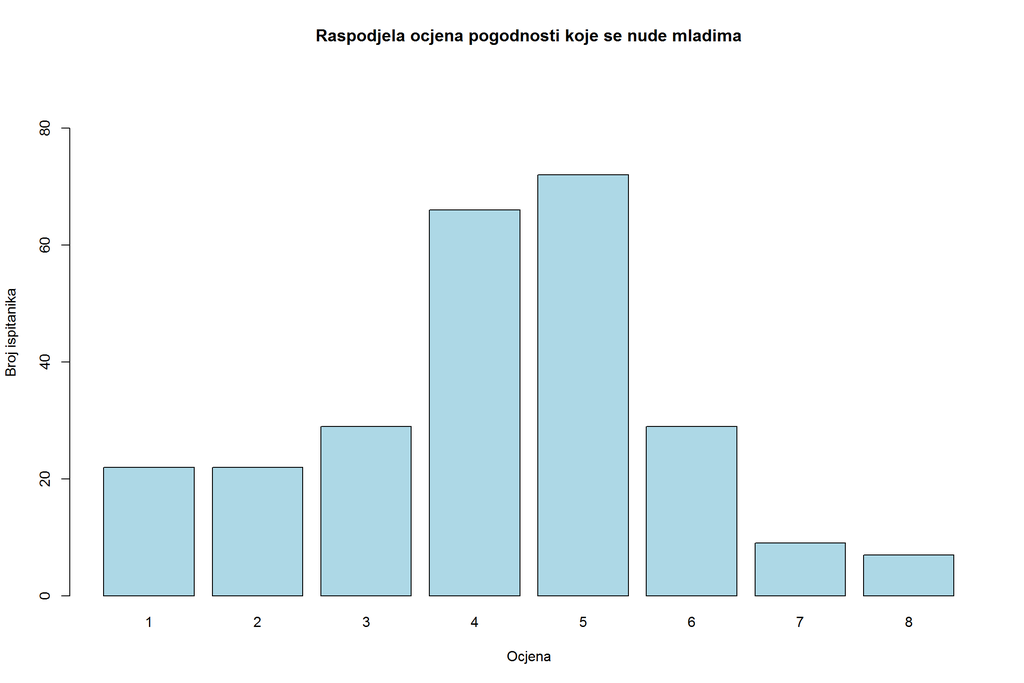

```r
barplot(table(tablicaMain$YouthBenefits), col=c("lightblue"), ylim = c(0, 90), xlab="Ocjena", ylab="Broj ispitanika", main="Raspodjela ocjena pogodnosti koje se nude mladima")
```

Prosječna ocjena je 4.17 (interval od 1 do 8). Standarna devijacija je 1.64 . Računom dobivamo da je interval pouzdanosti od 95% jednak od 3,97 do 4,39. Zaključke ne možemo dovoditi zbog upitne nezavisnosti podataka i nedostatka ispitanika iz određenih dobnih skupina.

### Raspodjela po bankama u kojima ispitanici imaju otvorene račune

```
## [1] "PBZ:  40.5405405405405 %"
```

```
## [1] "Zagrebačka:  29.7297297297297 %"
```

```
## [1] "Raiffeisen:  6.17760617760618 %"
```

```
## [1] "Splitska:  0.0926640926640927 %"
```

```
## [1] "Nemam račun:  3.47490347490348 %"
```

```
## [1] "Ostalo:  13.8996138996139 %"
```

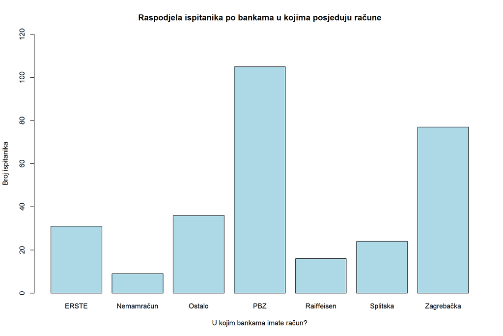

### Raspodjela po usluga koje banka nudi

```
## serv
##           Debitna ili kreditna kartica
##                                     83
##                    Internet bankarstvo
##                                     97
## Kontaktiranje Vašeg savjetnika u banci
##                                     12
##                     Mobilno bankarstvo
##                                     74
##           Ne koristim bankarske usluge
##                                     20
##                                 Ostalo
##                                     22
##                        Plaćanje računa
##                                     60
##              Provjera stanja na računu
##                                    143
##        Studentski paket (uljučuje sve)
##                                     94
##                                Štednja
##                                     57
```

```
## [1] "Debitna ili kreditna kartica:  32.046332046332 %"
```

```
## [1] "Internet bankarstvo:  37.4517374517375 %"
```

```
## [1] "Investiranje :  4.24710424710425 %"
```

```
## [1] "Kontaktiranje Vašeg savjetnika u banci:  4.63320463320463 %"
```

```
## [1] "Kredit:  0.0115830115830116 %"
```

```
## [1] "Mobilno bankarstvo :  28.5714285714286 %"
```

```
## [1] "Ne koristim bankarske usluge :  7.72200772200772 %"
```

```
## [1] "Osiguranje:  1.93050193050193 %"
```

```
## [1] "Ostalo: 1.15830115830116 %"
```

```
## [1] "Plaćanje računa: 23.1660231660232 %"
```

```
## [1] "Provjera stanja na računu:  55.2123552123552 %"
```

```
## [1] "Studentski paket (uključuje sve):  36.2934362934363 %"
```

```
## [1] "Štednja  22.007722007722 %"
```

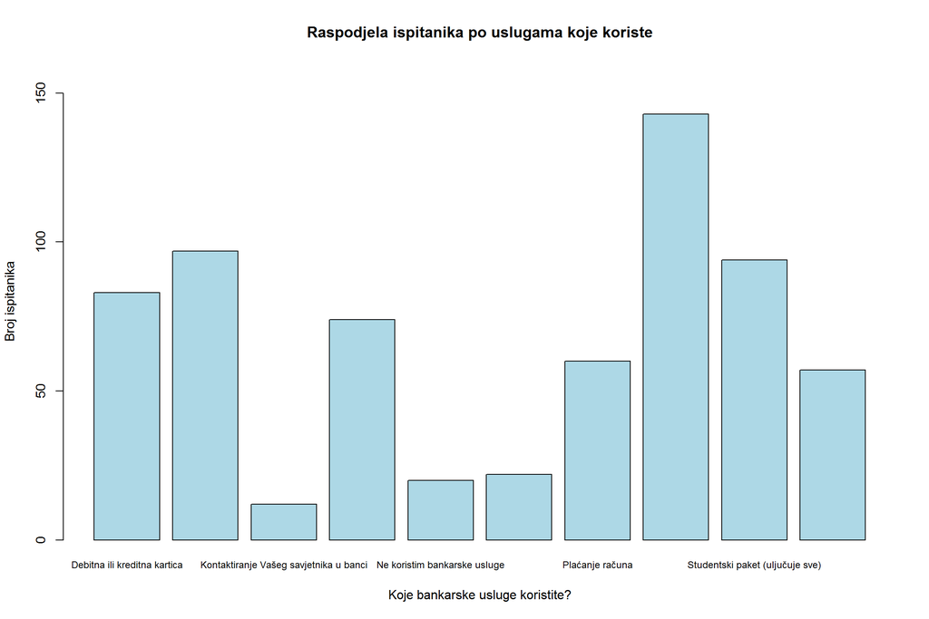

*Napomena: pojedine varijable su pridružene kategoriji “Ostalo” radi jednostavnosti grafa

Kategorija koja najviše odstupa je provjera stanja na računu, a tri kategorije koje su podjednako raspoređene su: Debitna ili kreditna kartica, Internet bankarstvo i Studentski paket. Valja uočiti da su Internet bankarstvo, pa čak i mobilno bankarstvo na relativnoj visokoj razini ali taj bi se postotak mogao povećati. Ostale kategorije nisu pretjerano izražene, iako se očekivalo da bi plaćanje računa bilo više zastupljeno.

### Raspodjela po razlogu da se počne koristiti ili da se više koristi Internet bankarstvo

```
## usage
##                          Besplatne transakcije
##                                            130
## Bolja uputstva za postavljanje Internet usluga
##                                             32
##                 Jednostavnija i jasnija usluga
##                                             78
##   Nagrade (smanjene cijene za određene usluge)
##                                            101
##                                         Ostalo
##                                             20
##    Sve je savršeno, ne bih ništa promijenio/la
##                                             24
##                                 Veća sigurnost
##                                             71
```

```
## [1] "Besplatne transakcije  50.1930501930502 %"
```

```
## [1] "Bolja uputstva za postavljanje Internet usluga:  12.3552123552124 %"
```

```
## [1] "Jednostavnija i jasnija usluga:  30.1158301158301 %"
```

```
## [1] " Nagrade (smanjene cijene za određene usluge):  38.996138996139 %"
```

```
## [1] "Ostalo:  0.0424710424710425 %"
```

```
## [1] "Sve je savršeno, ne bih ništa promijenio/la:  9.26640926640927 %"
```

```
## [1] "Telefonska pomoć pri postavljanju Internet usluga:  3.47490347490348 %"
```

```
## [1] "Veća sigurnost:  27.4131274131274 %"
```

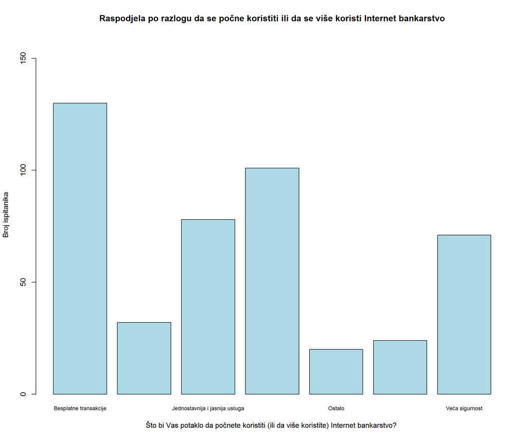

**Napomena: pojedine varijable su pridružene kategoriji “Ostalo” radi jednostavnosti grafa

Najzastupljenija varijabla su besplatne transakcije. Mladi imaju dosta uzak budžet, pa je to moguć razlog zašto im toliko smetaju naknade transakcija. Nagrade su druga po redu zastupljena varijabla koja se u bankama realizira pomoću loyalty programa. Vidljivo je da mladi imaju prilično veliku zainteresiranost za takve usluge i zbog toga bi se trebao napraviti loyalty program prilagođen samo tom dijelu populacije. Sigurnost i jasnija usluga su jednako raspodijeljeni i nose srednje velik udio, stoga su i ta područja otvorena za poboljšanja.

### Raspodjela po županijama u %

```
##
##     Brodsko-posavska županija                   Grad Zagreb
##                      0.781250                     55.078125
##             Istarska županija           Karlovačka županija
##                      5.078125                      0.390625
##           Krapinsko-zagorska            Međimurska županija
##                      1.171875                      2.734375
##    Požeško-slavonska županija   Primorsko-goranska županija
##                      0.390625                     11.328125
## Splitsko-dalmatinska županija          Varaždinska županija
##                      8.593750                      1.171875
## Vukovarsko-srijemska županija             Zadarska županija
##                      0.390625                      0.390625
##           Zagrebačka županija
##                     12.500000
```

Polovica ispitanika je iz grada Zagreba što i nije savršeno reprezantativno ako hoćemo promatrati preslikavanje na cijelu populaciju. Iz određenog broja županija uopće nije bilo odaziva.

### Ostali zanimljivi grafovi i promatranja

```r
##Significance level = 0.02

l=table(tablicaMain$Gender, tablicaMain$WhyBank)
prop.table(l, 2)*100
```

```
##
##                   Najbolji uvjeti i pogodnosti
##   Muško  52.94118                     54.76190
##   Žensko 47.05882                     45.23810
##
##          Preporuka prijatelja ili rodbine Pristupačnost
##   Muško                          38.65546      42.30769
##   Žensko                         61.34454      57.69231
```

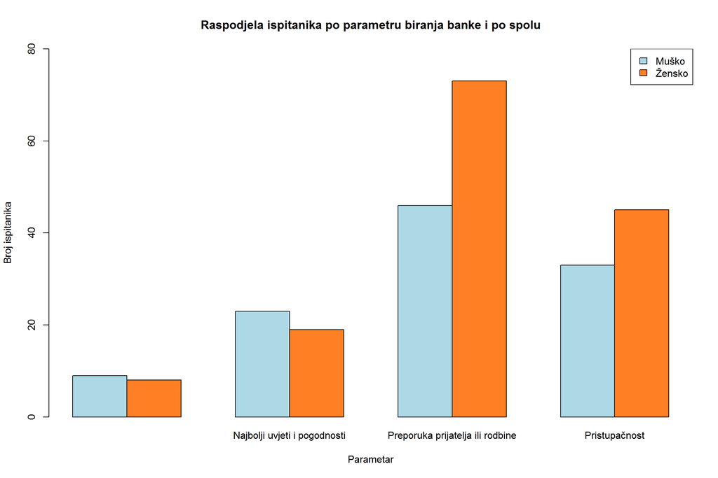

```r
barplot(l, col=c("lightblue", "chocolate1"), ylim = c(0, 80), xlab="Parametar", ylab="Broj ispitanika", main="Raspodjela ispitanika po parametru biranja banke i po spolu", beside=T )
legend("topright",     legend = c("Muško", "Žensko"),
       fill = c("lightblue", "chocolate1"))
```

```r
ppool=(46+73)/259
se=sqrt((ppool*(1-ppool)/46) + (ppool*(1-ppool)/73))

zScore= (0.613-0.387)/ se

p= 1-pnorm(zScore)
paste("p vrijednost:")
```

```
## [1] "p vrijednost:"
```

```r
2*p
```

```
## [1] 0.01599611
```

#### Učestalost korištenja bankomata po spolu

```r
##Significance level = 0.02

l=table(tablicaMain$Gender, tablicaMain$ATMUsage)
prop.table(l, 2)*100
```

```
##
##          Dva do četiri puta tjedno Jednom tjedno Jednom u dva tjedna
##   Muško                   41.66667      34.66667            49.51456
##   Žensko                  58.33333      65.33333            50.48544
##
##          Ne koristim bankomat Više od četiri puta tjedno
##   Muško              45.71429                   42.85714
##   Žensko             54.28571                   57.14286
```

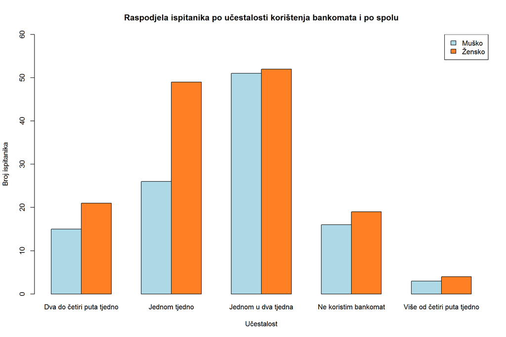

```r
barplot(l, col=c("lightblue", "chocolate1"), ylim = c(0, 60), xlab="Učestalost", ylab="Broj ispitanika", main="Raspodjela ispitanika po učestalosti korištenja bankomata i po spolu", beside=T )
legend("topright",     legend = c("Muško", "Žensko"),
       fill = c("lightblue", "chocolate1"))
```

```r
ppool=(49+26)/259
se=sqrt((ppool*(1-ppool)/49) + (ppool*(1-ppool)/26))

zScore= (0.653-0.346)/ se

p= 1-pnorm(zScore)
paste("p vrijednost:")
```

```
## [1] "p vrijednost:"
```

```r
2*p
```

```
## [1] 0.005276195
```

Ako razmatramo raspodjelu ispitanika po učestalosti korištenja bankomata, ali da ih još podijelimo po spolu, onda također zapažamo anomaliju u grafu. Udio žena koje jednom tjedno koriste bankomat je znatno veći od udjela muškaraca koji ga koriste jednom tjedno. Računom dobivamo da je ta hipoteza točna i odbacujemo hipotezu da su udjeli korištenja bankomata jednom tjedno jednaki između muškog i ženskog spola.

#### Ocjena bankarskih usluga po spolu raspodjela

```
##
##                 0        1        2        3        4        5        6
##   Muško  50.00000 52.38095 31.81818 36.27451 52.27273 57.69231 63.63636
##   Žensko 50.00000 47.61905 68.18182 63.72549 47.72727 42.30769 36.36364
```

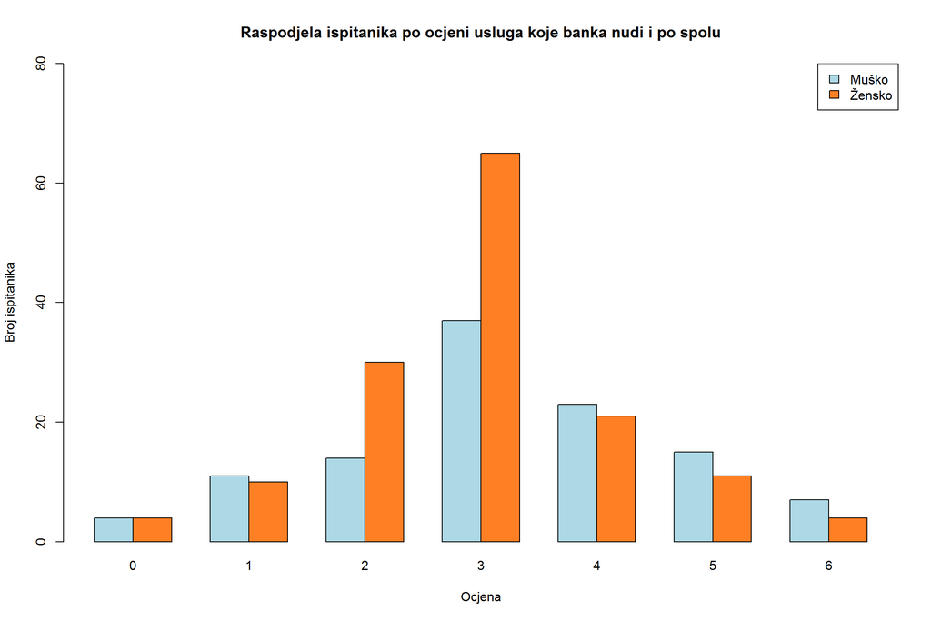

Može se uočiti da više žena daje ocjene 3 i 2, te da muškarci imaju nešto viši udio u davanju ocjena iznad 3.

### Napomene

Pitanje u kojem se tražilo od ispitanika da napišu koje funkcije bi htjeli dodati u mobilnu u aplikaciju nije ovdje analizirano već su samo odgovori prihvaćeni kao sugestije koje su razrađene u radu

## Literatura

David M. Diez, Christopher D. Barr, Mine Cetinkaya-Rundel, 2012., OpenIntro Statistics Second Edition, Duke University